# R Notebook

```r
library(ggnewscale)
library(sf)
library(tidyverse)
library(truchet)
```

Create a truchet tile:

```r
tile_1 <- st_truchet_p(type = "d")
```

Create mosaic:

```r
mosaic <- st_truchet_ms(tile_1)
```

Extract mosaic:

```r
container <- mosaic[["container"]]
mosaic <- mosaic[["mosaic"]]
```

```r
mosaic <- mosaic %>%
  mutate(id = 1:n())
```

```r
ggplot() +
  geom_sf(data = mosaic[28,])
```

Sample points:

```r
pts <- data.frame(geometry = st_geometry(st_sample(mosaic %>%
                                                     filter(color == 1),
                                                   size = 2500))) %>%
  st_as_sf() %>%
  st_set_agr("constant")
```

Plot:

```r
ggplot() +
  geom_sf(data = mosaic) +
  geom_sf(data = pts)
```

Id points:

```r
pts <- pts %>%
  st_join(mosaic %>%
            select(id))
```

Plot:

```r
ggplot() +
  geom_sf(data = mosaic) +
  geom_sf(data = pts %>%
            filter(id == 16))
```

Voronoi polygons:

```r
v <- st_voronoi(pts %>%
                  filter(id == 16) %>%
                  st_union()) %>%
  st_collection_extract() %>%
  st_intersection(mosaic %>%
                    filter(id == 16)) %>%
  st_sf() %>%
  mutate(id = 16,
         color = sample.int(10, n(), replace = TRUE))
```

Plot:

```r
ggplot() +
  geom_sf(data = v)
```

Now do for all polygons:

```r
v <- data.frame()
p_id <- mosaic %>%
  filter(color == 1) %>%
  pull(id)

count <- 0

for(i in p_id){
  count <- count +1
  v <- rbind(v,
             st_voronoi(pts %>%
                  filter(id == i) %>%
                  st_union()) %>%
  st_collection_extract() %>%
  st_intersection(mosaic %>%
                    filter(id == i)) %>%
  st_sf() %>%
  mutate(id = i,
         color = sample.int(5, n(), replace = TRUE)))
}

st_agr(v) < "constant"

v <- cbind(v,
           v %>%
             st_centroid() %>%
             st_coordinates())
```

Plot:

```r
ggplot() +
  geom_sf(data = v %>%
            mutate(color = sample.int(5, # Random colors across the board
                                      n(),
                                      replace = TRUE) +
                     rbinom(n(), # Random colors with a probability trend in function of X * Y
                            5,
                            prob = 1 - (X * Y)/(max(X) * max(Y))),
                   color = round(color)),
          aes(fill = factor(color)))
```

Make pretty:

```r
ggplot() +
  geom_sf(data = container,
          fill = "white") +
  geom_sf(data = v %>%
            mutate(color = sample.int(5, # Random colors across the board
                                      n(),
                                      replace = TRUE) +
                     rbinom(n(), # Random colors with a probability trend in function of X * Y
                            5,
                            prob = 1 - (X * Y)/(max(X) * max(Y))),
                   color = round(color)),
          aes(fill = color),
          color = "white") +
  theme_void() +
  theme(legend.position = "none")
```

## Test on a different mosaic:

Create a truchet tile:

```r
tile_1 <- st_truchet_p(type = "d")
```

Create mosaic:

```r
mosaic <- st_truchet_ms(tile_1, xlim = c(1, 6), ylim = c(1, 6))
```

Extract mosaic:

```r
container <- mosaic[["container"]]
mosaic <- mosaic[["mosaic"]]
```

Add ids to mosaic elements:

```r
mosaic <- mosaic %>%
  mutate(id = 1:n())
```

Sample points:

```r
pts <- data.frame(geometry = st_geometry(st_sample(mosaic %>%
                                                     filter(color == 1),
                                                   size = 500))) %>%
  st_as_sf() %>%
  st_set_agr("constant")
```

Id points:

```r
pts <- pts %>%
  st_join(mosaic %>%
            select(id))
```

Voronoi polygons:

```r
# Initialize data frame for voronoi polygons
v <- data.frame()

# Filter elements of the mosaic by color
p_id <- mosaic %>%
  filter(color == 1) %>%
  pull(id)

# Initialize count for colors
count <- 0

for(i in p_id){
  count <- count +1
  v <- rbind(v,
             st_voronoi(pts %>%
                  filter(id == i) %>%
                  st_union()) %>%
  st_collection_extract() %>%
  st_intersection(mosaic %>%
                    filter(id == i)) %>%
  st_sf() %>%
  mutate(id = i,
         color = sample.int(5, n(), replace = TRUE)))
}

v <- cbind(v,
           v %>%
             st_centroid() %>%
             st_coordinates())
```

Make pretty:

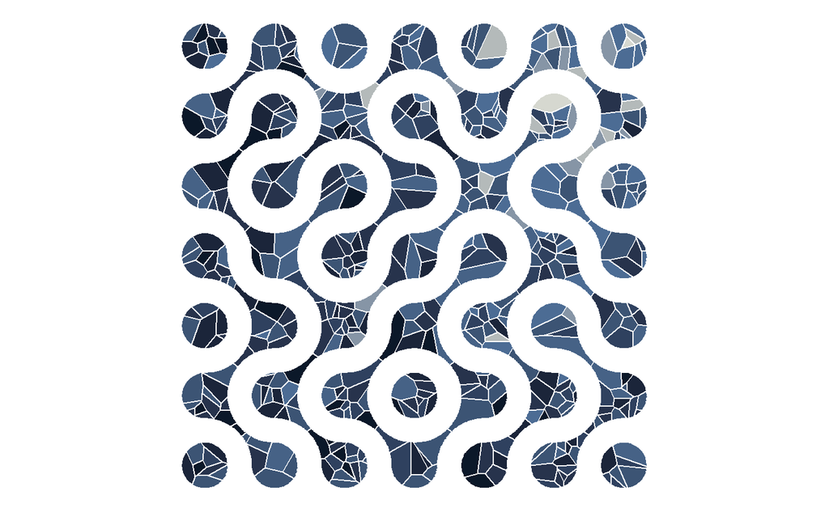

```r
col_palette <- MexBrewer::mex.brewer("Frida", n = 10)

ggplot() +
  geom_sf(data = container,
          fill = "white",
          color = NA) +
  geom_sf(data = v %>%
            mutate(color = color +
                     rbinom(n(), # Random colors with a probability trend in function of X * Y
                            5,
                            prob = 1 - (X * Y)/(max(X) * max(Y))),
                   color = round(color)),
          aes(fill = factor(color)),
          color = "white") +
  scale_fill_manual(values = col_palette) +
  theme_void() +
  theme(legend.position = "none")
```

## Layer a second set of voronoi polygons

Sample points:

```r
pts <- data.frame(geometry = st_geometry(st_sample(mosaic %>%
                                                     filter(color == 2),
                                                   size = 500))) %>%
  st_as_sf() %>%
  st_set_agr("constant")
```

Id points:

```r
pts <- pts %>%
  st_join(mosaic %>%
            select(id))
```

Voronoi polygons:

```r
# Initialize data frame for voronoi polygons
v_2 <- data.frame()

# Filter elements of the mosaic by color
p_id <- mosaic %>%
  filter(color == 2) %>%
  pull(id)

# Initialize count for colors
count <- 0

for(i in p_id){
  count <- count + 1
  v_2 <- rbind(v_2,
             st_voronoi(pts %>%
                  filter(id == i) %>%
                  st_union()) %>%
  st_collection_extract() %>%
  st_intersection(mosaic %>%
                    filter(id == i)) %>%
  st_sf() %>%
  mutate(id = i,
         color = sample.int(5, n(), replace = TRUE)))
}

v_2 <- cbind(v_2,
           v_2 %>%
             st_centroid() %>%
             st_coordinates())
```

Make pretty:

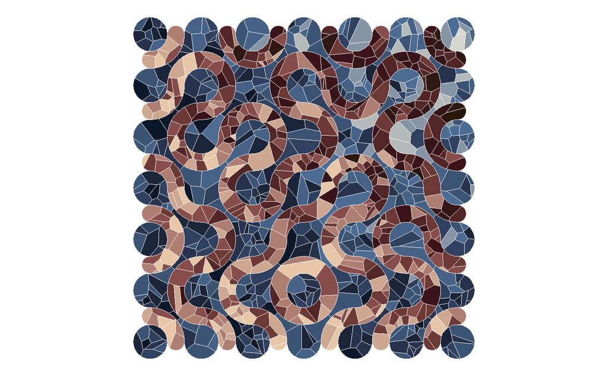

```r
col_palette <- MexBrewer::mex.brewer("Frida", n = 10)
col_palette_2 <- MexBrewer::mex.brewer("Aurora", n = 10)

ggplot() +
  geom_sf(data = v %>%
            mutate(color = color +
                     rbinom(n(), # Random colors with a probability trend in function of X * Y
                            5,
                            prob = 1 - (X * Y)/(max(X) * max(Y))),
                   color = round(color)),
          aes(fill = factor(color)),
          color = "white",
          size = 0.1) +
   scale_fill_manual(values = col_palette) +
  new_scale("fill") +
  geom_sf(data = v_2 %>%
            mutate(color = color +
                     rbinom(n(), # Random colors with a probability trend in function of X * Y
                            5,
                            prob = (X * Y)/(max(X) * max(Y))),
                   color = round(color)),
          aes(fill = factor(color)),
          color = "white",
          size = 0.1) +
  scale_fill_manual(values = col_palette_2) +
  theme_void() +
  theme(legend.position = "none")

ggsave("truchet-voronoi-frida-aurora.png")
```

## Change the tiles

Create a truchet tile:

```r
tile_1 <- st_truchet_p(type = "f")
```

Create mosaic:

```r
mosaic <- st_truchet_ms(tile_1,
                        xlim = c(1, 6),
                        ylim = c(1, 6))
```

Extract mosaic:

```r
container <- mosaic[["container"]]
mosaic <- mosaic[["mosaic"]]
```

Add ids to mosaic elements:

```r
mosaic <- mosaic %>%
  mutate(id = 1:n())
```

Sample points for first part of the mosaic:

```r
pts <- data.frame(geometry = st_geometry(st_sample(mosaic %>%
                                                     filter(color == 1),
                                                   size = 500))) %>%
  st_as_sf() %>%
  st_set_agr("constant")
```

Id points:

```r
pts <- pts %>%
  st_join(mosaic %>%
            select(id))
```

Voronoi polygons:

```r
# Initialize data frame for voronoi polygons
v <- data.frame()

# Filter elements of the mosaic by color
p_id <- mosaic %>%
  filter(color == 1) %>%
  pull(id)

# Initialize count for colors
count <- 0

for(i in p_id){
  count <- count +1
  v <- rbind(v,
             st_voronoi(pts %>%
                  filter(id == i) %>%
                  st_union()) %>%
  st_collection_extract() %>%
  st_intersection(mosaic %>%
                    filter(id == i)) %>%
  st_sf() %>%
  mutate(id = i,
         color = sample.int(5, n(), replace = TRUE)))
}

v <- cbind(v,
           v %>%
             st_centroid() %>%
             st_coordinates())
```

Sample points for complement of mosaic:

```r
pts <- data.frame(geometry = st_geometry(st_sample(mosaic %>%
                                                     filter(color == 2),
                                                   size = 1000))) %>%
  st_as_sf() %>%
  st_set_agr("constant")
```

Id points:

```r
pts <- pts %>%
  st_join(mosaic %>%
            select(id))
```

Voronoi polygons:

```r
# Initialize data frame for voronoi polygons
v_2 <- data.frame()

# Filter elements of the mosaic by color
p_id <- mosaic %>%
  filter(color == 2) %>%
  pull(id)

# Initialize count for colors
count <- 0

for(i in p_id){
  count <- count + 1
  v_2 <- rbind(v_2,
             st_voronoi(pts %>%
                  filter(id == i) %>%
                  st_union()) %>%
  st_collection_extract() %>%
  st_intersection(mosaic %>%
                    filter(id == i)) %>%
  st_sf() %>%
  mutate(id = i,
         color = sample.int(5, n(), replace = TRUE)))
}

v_2 <- cbind(v_2,
           v_2 %>%
             st_centroid() %>%
             st_coordinates())
```

Make pretty:

[figure not shown]

## MORE!

Create a truchet tile:

```r
tile_1 <- st_truchet_p(type = "-")
tile_2 <- st_truchet_p(type = "-", scale_p = 1/2)
```

Create mosaic:

```r
mosaic <- st_truchet_ms(tile_1, tile_2,
                        xlim = c(1, 4),
                        ylim = c(1, 4))
```

Extract mosaic:

```r
container <- mosaic[["container"]]
mosaic <- mosaic[["mosaic"]]
```

Add ids to mosaic elements:

```r
mosaic <- mosaic %>%
  mutate(id = 1:n())
```

Sample points for first part of the mosaic:

```r
pts <- data.frame(geometry = st_geometry(st_sample(mosaic %>%
                                                     filter(color == 1),
                                                   size = 2000))) %>%
  st_as_sf() %>%
  st_set_agr("constant")
```

Id points:

```r
pts <- pts %>%
  st_join(mosaic %>%
            select(id))
```

Voronoi polygons:

```r
# Initialize data frame for voronoi polygons
v <- data.frame()

# Filter elements of the mosaic by color
p_id <- mosaic %>%
  filter(color == 1) %>%
  pull(id)

# Initialize count for colors
count <- 0

for(i in p_id){
  count <- count +1
  v <- rbind(v,
             st_voronoi(pts %>%
                  filter(id == i) %>%
                  st_union()) %>%
  st_collection_extract() %>%
  st_intersection(mosaic %>%
                    filter(id == i)) %>%
  st_sf() %>%
  mutate(id = i,
         color = sample.int(5, n(), replace = TRUE)))
}
v <- cbind(v,
           v %>%
             st_centroid() %>%
             st_coordinates())
```

Sample points for complement of mosaic:

```r
pts <- data.frame(geometry = st_geometry(st_sample(mosaic %>%
                                                     filter(color == 2),
                                                   size = 1000))) %>%
  st_as_sf() %>%
  st_set_agr("constant")
```

Id points:

```r
pts <- pts %>%
  st_join(mosaic %>%
            select(id))
```

Voronoi polygons:

```r
# Initialize data frame for voronoi polygons
v_2 <- data.frame()

# Filter elements of the mosaic by color
p_id <- mosaic %>%
  filter(color == 2) %>%
  pull(id)

# Initialize count for colors
count <- 0

for(i in p_id){
  count <- count + 1
  v_2 <- rbind(v_2,
             st_voronoi(pts %>%
                  filter(id == i) %>%
                  st_union()) %>%
  st_collection_extract() %>%
  st_intersection(mosaic %>%
                    filter(id == i)) %>%
  st_sf() %>%
  mutate(id = i,
         color = sample.int(5, n(), replace = TRUE)))
}

v_2 <- cbind(v_2,
           v_2 %>%
             st_centroid() %>%
             st_coordinates())
```

Make pretty:

```r
col_palette <- MexBrewer::mex.brewer("Frida", n = 10)
col_palette_2 <- MexBrewer::mex.brewer("Tierra", n = 10)

ggplot() +
  geom_sf(data = mosaic %>%
            filter(color == 1),
          color = NA,
          fill = col_palette[7]) +
  geom_sf(data = mosaic %>%
            filter(color == 2),
          color = NA,
          fill = col_palette_2[7]) +
  #geom_sf(data = v %>%
  #          mutate(color = color +
  #                   rbinom(n(), # Random colors with a probability trend in function of X * Y
  #                          5,
  #                          prob = 1 - (X * Y)/(max(X) * max(Y))),
  #                 color = round(color)),
  #        aes(fill = factor(color)),
  #        color = "white",
  #        size = 0.1) +
   scale_fill_manual(values = col_palette) +
  new_scale("fill") +
  geom_sf(data = v_2 %>%
            mutate(color = color +
                     rbinom(n(), # Random colors with a probability trend in function of X * Y
                            5,
                            prob = (X * Y)/(max(X) * max(Y))),
                   color = round(color)),
          aes(fill = factor(color)),
          color = "white",
          size = 0.2) +
  scale_fill_manual(values = col_palette_2) +
  theme_void() +
  theme(legend.position = "none")

ggsave("truchet-voronoi-frida-tierra.png")
```

[output not shown]

## AND MORE!

Create a truchet tile:

```r
tile_1 <- st_truchet_p(type = "f")
tile_2 <- st_truchet_p(type = "f", scale_p = 1/2)
```

Create mosaic:

```r
mosaic <- st_truchet_ms(tile_1, tile_2,
                        xlim = c(1, 4),
                        ylim = c(1, 4))
```

Extract mosaic:

```r
container <- mosaic[["container"]]
mosaic <- mosaic[["mosaic"]]
```

Add ids to mosaic elements:

```r
mosaic <- mosaic %>%
  mutate(id = 1:n())
```

Sample points for first part of the mosaic:

```r
pts <- data.frame(geometry = st_geometry(st_sample(mosaic %>%
                                                     filter(color == 1),
                                                   size = 2000))) %>%
  st_as_sf() %>%
  st_set_agr("constant")
```

Id points:

```r
pts <- pts %>%
  st_join(mosaic %>%
            select(id))
```

Voronoi polygons:

```r
# Initialize data frame for voronoi polygons
v <- data.frame()

# Filter elements of the mosaic by color
p_id <- mosaic %>%
  filter(color == 1) %>%
  pull(id)

# Initialize count for colors
count <- 0

for(i in p_id){
  count <- count +1
  v <- rbind(v,
             st_voronoi(pts %>%
                  filter(id == i) %>%
                  st_union()) %>%
  st_collection_extract() %>%
  st_intersection(mosaic %>%
                    filter(id == i)) %>%
  st_sf() %>%
  mutate(id = i,
         color = sample.int(5, n(), replace = TRUE)))
}
v <- cbind(v,
           v %>%
             st_centroid() %>%
             st_coordinates())
```

Sample points for complement of mosaic:

```r
pts <- data.frame(geometry = st_geometry(st_sample(mosaic %>%
                                                     filter(color == 2),
                                                   size = 1000))) %>%
  st_as_sf() %>%
  st_set_agr("constant")
```

Id points:

```r
pts <- pts %>%
  st_join(mosaic %>%
            select(id))
```

Voronoi polygons:

```r
# Initialize data frame for voronoi polygons
v_2 <- data.frame()

# Filter elements of the mosaic by color
p_id <- mosaic %>%
  filter(color == 2) %>%
  pull(id)

# Initialize count for colors
count <- 0

for(i in p_id){
  count <- count + 1
  v_2 <- rbind(v_2,
             st_voronoi(pts %>%
                  filter(id == i) %>%
                  st_union()) %>%
  st_collection_extract() %>%
  st_intersection(mosaic %>%
                    filter(id == i)) %>%
  st_sf() %>%
  mutate(id = i,
         color = sample.int(5, n(), replace = TRUE)))
}

v_2 <- cbind(v_2,
           v_2 %>%
             st_centroid() %>%
             st_coordinates())
```

Make pretty:

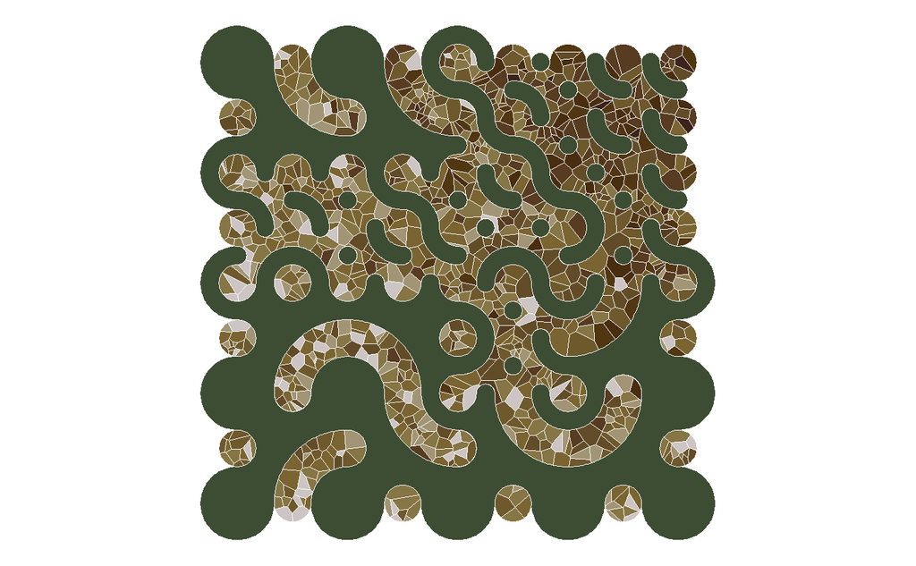

```r
col_palette <- MexBrewer::mex.brewer("Concha", n = 10)
col_palette_2 <- MexBrewer::mex.brewer("Tierra", n = 10)

ggplot() +
  geom_sf(data = mosaic %>%
            filter(color == 1),
          color = NA,
          fill = col_palette[7]) +
  geom_sf(data = mosaic %>%
            filter(color == 2),
          color = NA,
          fill = col_palette_2[7]) +
  #geom_sf(data = v %>%
  #          mutate(color = color +
  #                   rbinom(n(), # Random colors with a probability trend in function of X * Y
  #                          5,
  #                          prob = 1 - (X * Y)/(max(X) * max(Y))),
  #                 color = round(color)),
  #        aes(fill = factor(color)),
  #        color = "white",
  #        size = 0.1) +
   scale_fill_manual(values = col_palette) +
  new_scale("fill") +
  geom_sf(data = v_2 %>%
            mutate(color = color +
                     rbinom(n(), # Random colors with a probability trend in function of X * Y
                            5,
                            prob = (X * Y)/(max(X) * max(Y))),
                   color = round(color)),
          aes(fill = factor(color)),
          color = "white",
          size = 0.2) +
  scale_fill_manual(values = col_palette_2) +
  theme_void() +
  theme(legend.position = "none")

ggsave("truchet-voronoi-concha-tierra.png")
```